# Homework 5

Cathy Zhuang

14 November, 2023

**Due November 15 prior to 1:30 PM. Assignments are to be submitted via Canvas.**

**You may discuss the homework problems and computing issues with other students in the class and submit questions to the Canvas discussion board. However, you must write up your homework solution on your own. In particular, do not share your R files with other students. Please list the students you worked with below.**

Students worked with: Same as last time

Lectures: Module 5

Objectives:

1. Fit and interpret an additive model.
2. Examine different basis functions and smoothing parameter selection in mgcv::gam.
3. Model the interaction between a factor and continuous variable in GAMs.

# 1 Problem 1.

In general, people experience a decline in cognitive function with age. Dementia is defined as serious cognitive decline that impacts everyday activities. People with mild cognitive impairment (MCI) are generally able to perform daily activities, but have greater decline in cognitive function than in typical aging. Many people with MCI eventually develop Alzheimer’s Disease or other types of dementia.

We will use a dataset containing an imaging biomarker, a genetic biomarker, and demographic information, defined below. The dataset (MCI.RData) contains data related to the Alzheimer’s Disease Neuroimaging Initiative (http://adni.loni.usc.edu/tadpole-challenge-dataset-available/). Parts of the data have been simulated in order to allow data sharing for educational purposes. Qualitatively, the results you discover in this educational dataset are likely to be the same as in the unaltered dataset.

Variable Codebook:

1. ID Participant identifier.
2. VISIT Visit time in months since baseline.
3. DX
- 0 = normal aging
- 1 = MCI
4. AGE_VISIT Participant’s age at the time of the visit.
5. PTGENDER Participant gender.
- Female
- Male
6. PTEDUCAT Total years of education.
7. APOE4 Numeric variable equal to 0, 1, or 2 indicating the individual has 0, 1, or 2 copies of the E4 allele of apolipoprotein. This genetic variant is linked to the formation of amyloid beta deposits in the brain, which is one of the characteristics of Alzheimer’s Disease.
8. HIPPOCAMPUS_VOL Volume of the right plus left hippocampus in mm^3. The hippocampus is a subcortical gray matter structure in the brain that is associated with memory.

We will subset to cross-sectional data. We do this for educational purposes, as we want to fit variants of the model a few times to understand the effects of different spline specifications. It takes a long time to fit the longitudinal gam. So for this homework, it is easier to work with the cross-sectional data. Please note that in your own research projects and future jobs, you will of course want to use all of your data.

Create the cross-sectional dataset and convert hippocampus volume to cm^3:

```r
# set the working directory
setwd("C:\\Git\\Modern-Regression-Analysis-Fall2023\\Data")
load("MCI.RData")
mcidata$HIPPOCAMPUS_VOL=mcidata$HIPPOCAMPUS_VOL/1000
mcidata$APOE4 = factor(mcidata$APOE4)
mcidata = mcidata[complete.cases(mcidata),]
mcidata_cx = mcidata[!duplicated(mcidata$ID),]
```

## 1.1

Using mathematical notation, with $g_j(x_{ij})$ for smooth terms, write out a statistical model with normal errors for the cross-sectional data with $y_i$ denoting hippocampus volume in cm^3 and the covariates `DX`, `PTGENDER`, `APOE4` (treating APOE4 as a factor with reference level 0), a smooth for `AGE_VISIT`, and a smooth for `PTEDUCAT`. Include distributional assumptions. (You do not need to write the basis functions used for the smooth terms $g_j(x_{ij})$, nor the penalized objective function.)

$$y_i \overset{iid}{\sim} N (\mu_i,
\sigma^2)$$
where $y_i$ is hippocampus volume in cm^3 for individual i.

$$y_i = \beta_0 + \beta_1 DX_i + \beta_2
PTGENDER_i + \beta_3 APOE4_{1i} + \beta_4APOE4_{2i} + g_1(AGEVISIT_i) +
g_2(PTEDUCAT_i) + \epsilon$$

$$\epsilon \overset{iid}{\sim} N (0,
\sigma^2)$$
where $\epsilon$ is our error and $\sigma^2$ is our variance.

$\beta_0$ is the baseline hippocampal volume without considering other covariates.  
$\beta_1$ is the estimated effect for diagnosis, with 0 as the reference level. $\beta_2$ is the estimated effect for gender, with female as the reference level. $\beta_3$ is the estimated effect for APOE4 with 1 copy of the allele, with the reference group being 0. $\beta_4$ is the estimated effect for APOE4 with 2 copies of the allele, with the reference group being 0. $g_1(AGEVISIT_i)$ is the smoothing term for age_visit. $g_2(PTEDUCAT_i)$ is the smoothing term for pteducat.

## 1.2

Fit this model using `mgcv::gam`. Use all defaults. Print the output of summary.

```r
library(mgcv)
mcidata_cx$APOE4 <- as.factor(mcidata_cx$APOE4)
q2 <- gam(HIPPOCAMPUS_VOL~s(AGE_VISIT)+s(PTEDUCAT)+DX+PTGENDER+APOE4, data= mcidata_cx)
summary(q2)
```

```
##
## Family: gaussian
## Link function: identity
##
## Formula:
## HIPPOCAMPUS_VOL ~ s(AGE_VISIT) + s(PTEDUCAT) + DX + PTGENDER +
##     APOE4
##
## Parametric coefficients:
##              Estimate Std. Error t value Pr(>|t|)
## (Intercept)   6.90924    0.06425 107.530  < 2e-16 ***
## DX           -0.86349    0.07042 -12.263  < 2e-16 ***
## PTGENDERMale  0.42804    0.06699   6.390 2.73e-10 ***
## APOE41       -0.23431    0.07088  -3.306 0.000987 ***
## APOE42       -0.69546    0.12882  -5.399 8.72e-08 ***
## ---
## Signif. codes:  0 '***' 0.001 '**' 0.01 '*' 0.05 '.' 0.1 ' ' 1
##
## Approximate significance of smooth terms:
##                edf Ref.df      F p-value
## s(AGE_VISIT) 2.046  2.597 98.630  <2e-16 ***
## s(PTEDUCAT)  1.939  2.458  0.784   0.557
## ---
## Signif. codes:  0 '***' 0.001 '**' 0.01 '*' 0.05 '.' 0.1 ' ' 1
##
## R-sq.(adj) =  0.342   Deviance explained = 34.8%
## GCV = 0.91312  Scale est. = 0.90356   n = 858
```

## 1.3

Create diagnostic plots using `gam.check()`. Briefly comment on each of the four plots. Are there any issues?

For the deviance residuals plot, the data fits well and does not deviate too much from the straight line. This suggests that our normality assumption is not violated. For the residuals vs. linear predictor plot, the residuals appear to be randomly scattered around zero, which means that the model may be adequate for capturing the underlying relationship of our data. For the response vs. fitted values plot, it should look linear if k is sufficient, in which it does. Finally, the histogram of residuals appears to be normal. Visually, it appears that there may be no issues.

The k-index for PTEDUCAT is slightly less than 1, which may mean that it is underfitted.

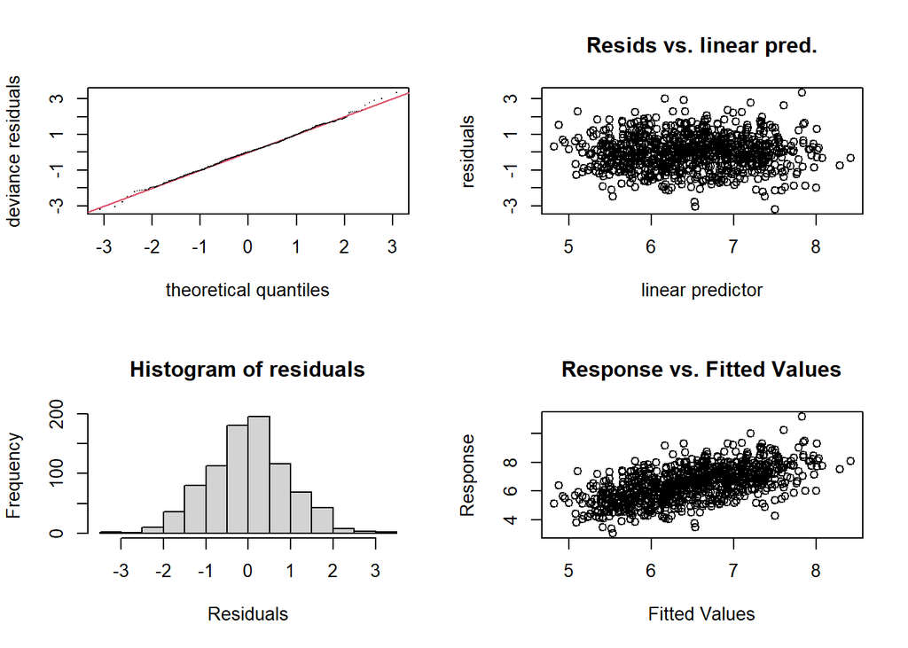

```
##
## Method: GCV   Optimizer: magic
## Smoothing parameter selection converged after 6 iterations.
## The RMS GCV score gradient at convergence was 3.819307e-06 .
## The Hessian was positive definite.
## Model rank =  23 / 23
##
## Basis dimension (k) checking results. Low p-value (k-index<1) may
## indicate that k is too low, especially if edf is close to k'.
##
##                k'  edf k-index p-value
## s(AGE_VISIT) 9.00 2.05    1.01   0.600
## s(PTEDUCAT)  9.00 1.94    0.93   0.025 *
## ---
## Signif. codes:  0 '***' 0.001 '**' 0.01 '*' 0.05 '.' 0.1 ' ' 1
```

```r
gam.check(q2)
```

## 1.4

State the null hypothesis for each p-value in the spline basis dimension diagnostics in `gam.check()`. Then state whether it is accepted or rejected at $\alpha=0.05$.

## 1.5

Next, inspect the effective degrees of freedom versus k’ in `gam.check()`. Does this approach suggest that k is adequate?

In general, we want to see k’ to be “notably” larger than edf to show that we have indeed tried enough dimensions. Here, our k’ is 9 for both smooths, and the edfs are 2.05 and 1.94, so k’ is indeed “notably” larger than the edfs. So this suggests that k is adequate.

## 1.6

Try to refit the model with k=20 for `PTEDUCAT`. Why did you receive an error?

The term has fewer unique covariate combinations than specified maximum degrees of freedom. k=20 is larger than the number of categories for PTEDUCAT.

```r
# q6 <- gam(HIPPOCAMPUS_VOL~s(AGE_VISIT)+s(PTEDUCAT, k=20)+DX+PTGENDER+APOE4, data= mcidata_cx)
```

## 1.7

Re-fit the model with k set to the maximum possible for `PTEDUCAT`. Print the results of `gam.check()`. Did the edf change? Using the criteria of the change in edf, is k=10 sufficient for modeling the impact of `PTEDUCAT`?

The edf decreased slightly. Using the criteria of the change in edf, k=10 is sufficient for modeling the impact of `PTEDUCAT` since we did not need to use more dimensions.

```r
q7 <- gam(HIPPOCAMPUS_VOL~s(AGE_VISIT)+s(PTEDUCAT, k=length(unique(mcidata_cx$PTEDUCAT)))+DX+PTGENDER+APOE4, data= mcidata_cx)
summary(q7)
```

```
##
## Family: gaussian
## Link function: identity
##
## Formula:
## HIPPOCAMPUS_VOL ~ s(AGE_VISIT) + s(PTEDUCAT, k = length(unique(mcidata_cx$PTEDUCAT))) +
##     DX + PTGENDER + APOE4
##
## Parametric coefficients:
##              Estimate Std. Error t value Pr(>|t|)
## (Intercept)   6.90927    0.06425 107.530  < 2e-16 ***
## DX           -0.86348    0.07042 -12.262  < 2e-16 ***
## PTGENDERMale  0.42800    0.06699   6.389 2.74e-10 ***
## APOE41       -0.23434    0.07088  -3.306 0.000985 ***
## APOE42       -0.69551    0.12882  -5.399 8.71e-08 ***
## ---
## Signif. codes:  0 '***' 0.001 '**' 0.01 '*' 0.05 '.' 0.1 ' ' 1
##
## Approximate significance of smooth terms:
##                edf Ref.df      F p-value
## s(AGE_VISIT) 2.046  2.596 98.670  <2e-16 ***
## s(PTEDUCAT)  1.912  2.427  0.772   0.559
## ---
## Signif. codes:  0 '***' 0.001 '**' 0.01 '*' 0.05 '.' 0.1 ' ' 1
##
## R-sq.(adj) =  0.342   Deviance explained = 34.8%
## GCV = 0.91313  Scale est. = 0.9036    n = 858
```

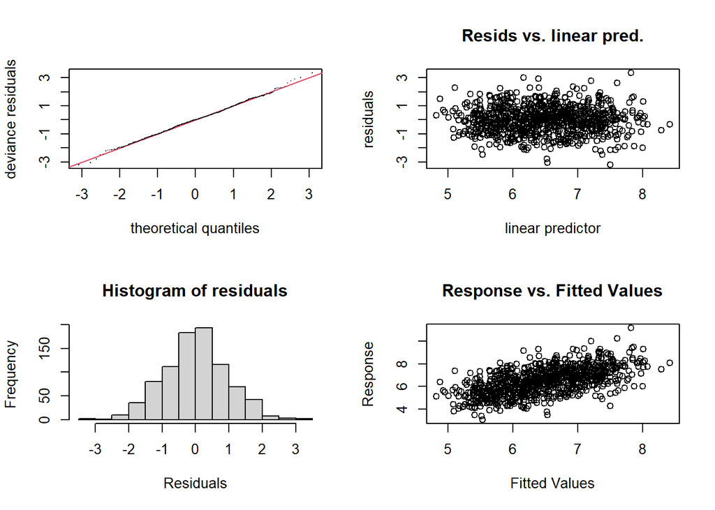

```
##
## Method: GCV   Optimizer: magic
## Smoothing parameter selection converged after 4 iterations.
## The RMS GCV score gradient at convergence was 6.830394e-08 .
## The Hessian was positive definite.
## Model rank =  28 / 28
##
## Basis dimension (k) checking results. Low p-value (k-index<1) may
## indicate that k is too low, especially if edf is close to k'.
##
##                 k'   edf k-index p-value
## s(AGE_VISIT)  9.00  2.05    1.01    0.59
## s(PTEDUCAT)  14.00  1.91    0.93    0.02 *
## ---
## Signif. codes:  0 '***' 0.001 '**' 0.01 '*' 0.05 '.' 0.1 ' ' 1
```

```r
gam.check(q7)
```

## 1.8

Let’s go back to the model with defaults k=10 from 1.2. Create a plot of the smooth for `AGE_VISIT` using `plot()`.

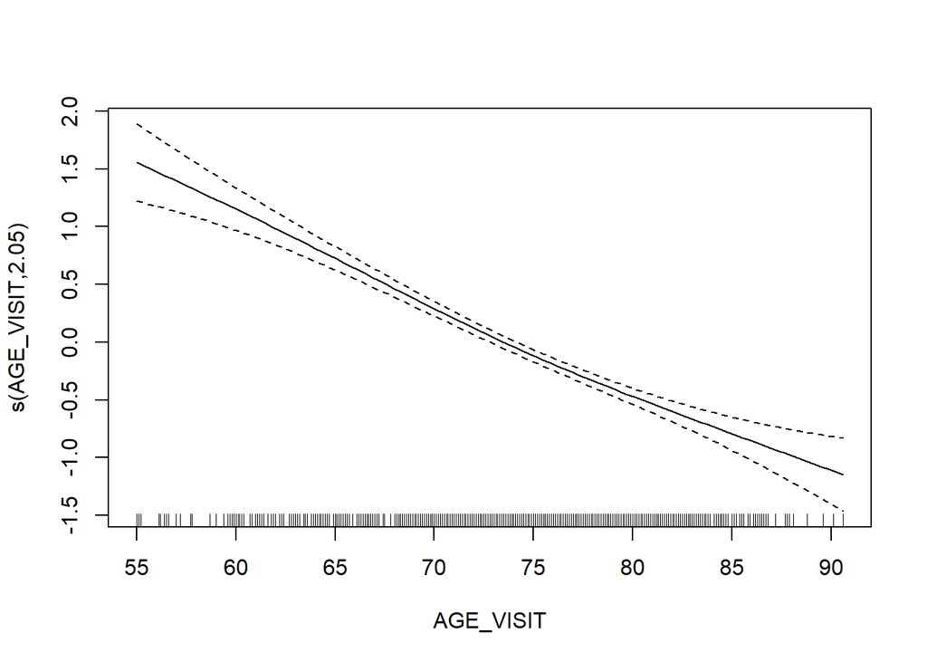

```r
plot(q2, select=1)
```

## 1.9

Now create a plot of the smooth for `AGE_VISIT` using `itsadug::plot_smooth()`.

```r
library(itsadug)
```

```
## Summary:
##  * DX : numeric predictor; set to the value(s): 1.
##  * PTGENDER : factor; set to the value(s): Male.
##  * APOE4 : factor; set to the value(s): 0.
##  * AGE_VISIT : numeric predictor; with 30 values ranging from 55.000000 to 90.600000.
##  * PTEDUCAT : numeric predictor; set to the value(s): 16.
##  * NOTE : No random effects in the model to cancel.
##
```

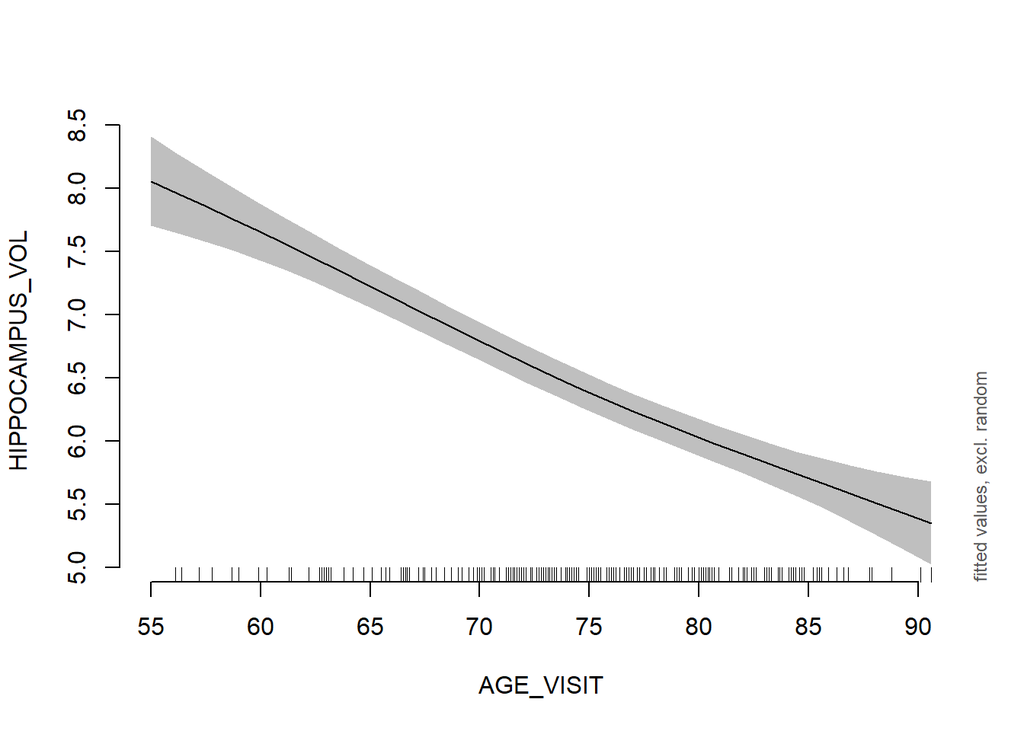

```r
itsadug::plot_smooth(q2, view="AGE_VISIT")
```

## 1.10

What does the black curve in 1.9 represent? Use your notation from 1.1. What does the black curve in 1.8 represent?

Black curve in 1.9 is $\hat{y_i} = \hat{\beta_0} + \hat{\beta_1}(1) + \hat{\beta_2}(1) + \hat{g_1}(AGEVISIT_i) + \hat{g_2}(PTEDUCAT_i=16)$

Black curve in 1.8 is $\hat{g_1}(AGEVISIT_i)$.

## 1.11

Write out the coefficient estimates and the parametric term values that contribute to the standard errors used in the confidence intervals in 1.9. For example, if only the intercept, $x_{i1}=1$ and the smooth for `AGE_VISIT` contribute, the formula would be $Var [ \hat{\beta}_0+\hat{\beta}_1 *1 + \hat{g}(AGE\_VISIT)]$. Do the same for the terms that contribute to the standard errors used in 1.8.

1.9: $Var[\hat{\beta_0} + \hat{\beta_1}(1) + \hat{\beta_2}(1) + \hat{g_1}(AGEVISIT_i) + \hat{g_2}(PTEDUCAT_i=16)]$

1.8: $Var[\hat{g_1}(AGEVISIT_i)]$

## 1.12

Re-fit the model with cubic regression splines for both smooth terms. Use k=10. Print the output of `summary()`.

```r
q12 <- gam(HIPPOCAMPUS_VOL~s(AGE_VISIT, bs='cr')+s(PTEDUCAT, bs='cr')+DX+PTGENDER+APOE4, data= mcidata_cx)
summary(q12)
```

```
##
## Family: gaussian
## Link function: identity
##
## Formula:
## HIPPOCAMPUS_VOL ~ s(AGE_VISIT, bs = "cr") + s(PTEDUCAT, bs = "cr") +
##     DX + PTGENDER + APOE4
##
## Parametric coefficients:
##              Estimate Std. Error t value Pr(>|t|)
## (Intercept)   6.90925    0.06425 107.530  < 2e-16 ***
## DX           -0.86358    0.07042 -12.263  < 2e-16 ***
## PTGENDERMale  0.42807    0.06699   6.391 2.72e-10 ***
## APOE41       -0.23427    0.07088  -3.305 0.000989 ***
## APOE42       -0.69544    0.12882  -5.398 8.73e-08 ***
## ---
## Signif. codes:  0 '***' 0.001 '**' 0.01 '*' 0.05 '.' 0.1 ' ' 1
##
## Approximate significance of smooth terms:
##                edf Ref.df     F p-value
## s(AGE_VISIT) 2.055  2.606 98.03  <2e-16 ***
## s(PTEDUCAT)  1.954  2.474  0.52   0.555
## ---
## Signif. codes:  0 '***' 0.001 '**' 0.01 '*' 0.05 '.' 0.1 ' ' 1
##
## R-sq.(adj) =  0.342   Deviance explained = 34.8%
## GCV = 0.91311  Scale est. = 0.90352   n = 858
```

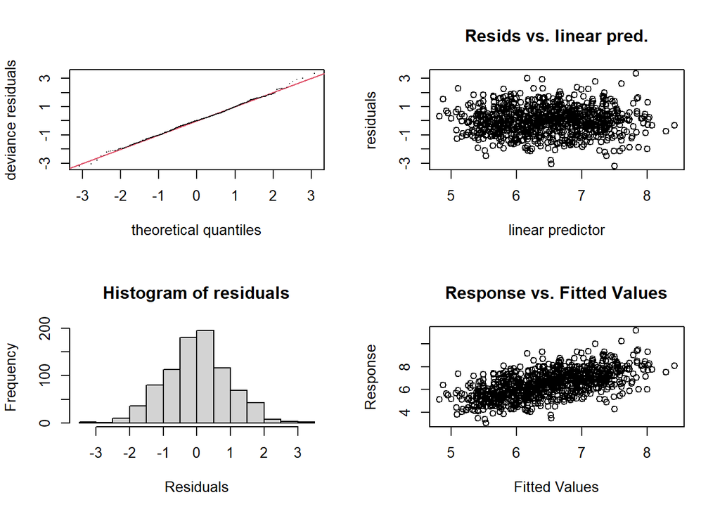

```
##
## Method: GCV   Optimizer: magic
## Smoothing parameter selection converged after 5 iterations.
## The RMS GCV score gradient at convergence was 4.184599e-07 .
## The Hessian was positive definite.
## Model rank =  23 / 23
##
## Basis dimension (k) checking results. Low p-value (k-index<1) may
## indicate that k is too low, especially if edf is close to k'.
##
##                k'  edf k-index p-value
## s(AGE_VISIT) 9.00 2.06    1.01   0.580
## s(PTEDUCAT)  9.00 1.95    0.93   0.015 *
## ---
## Signif. codes:  0 '***' 0.001 '**' 0.01 '*' 0.05 '.' 0.1 ' ' 1
```

```r
gam.check(q12)
```

## 1.13

Create a plot of the smooth for `AGE_VISIT` from the previous question. For this and all questions hereafter regarding plotting smooths, use `itsadug::plot_smooth()`. How does it compare to the smooth from the thin plate regression spline? Hint: you can use `add=TRUE` in `plot_smooth()` to overlay functions.

It appears that they are the same.

```r
itsadug::plot_smooth(q2, view="AGE_VISIT", col="red")
```

```
## Summary:
##  * DX : numeric predictor; set to the value(s): 1.
##  * PTGENDER : factor; set to the value(s): Male.
##  * APOE4 : factor; set to the value(s): 0.
##  * AGE_VISIT : numeric predictor; with 30 values ranging from 55.000000 to 90.600000.
##  * PTEDUCAT : numeric predictor; set to the value(s): 16.
##  * NOTE : No random effects in the model to cancel.
##
```

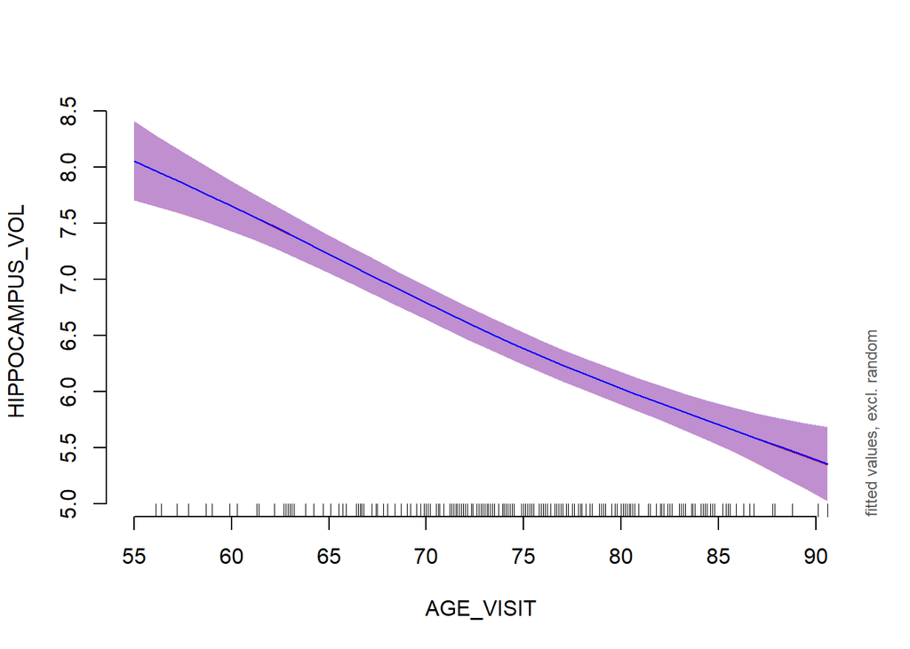

```
## Summary:
##  * DX : numeric predictor; set to the value(s): 1.
##  * PTGENDER : factor; set to the value(s): Male.
##  * APOE4 : factor; set to the value(s): 0.
##  * AGE_VISIT : numeric predictor; with 30 values ranging from 55.000000 to 90.600000.
##  * PTEDUCAT : numeric predictor; set to the value(s): 16.
##  * NOTE : No random effects in the model to cancel.
##
```

```r
itsadug::plot_smooth(q12, view="AGE_VISIT", add=TRUE, col="blue")
```

## 1.14

Now fit the model with thin plate regression splines (i.e., going back to the default splines) using the mixed model random slope approach with REML for tuning parameter selection instead of GCV.

```r
q14 <- gam(HIPPOCAMPUS_VOL~s(AGE_VISIT)+s(PTEDUCAT)+DX+PTGENDER+APOE4, data= mcidata_cx, method="REML")
summary(q14)
```

```
##
## Family: gaussian
## Link function: identity
##
## Formula:
## HIPPOCAMPUS_VOL ~ s(AGE_VISIT) + s(PTEDUCAT) + DX + PTGENDER +
##     APOE4
##
## Parametric coefficients:
##              Estimate Std. Error t value Pr(>|t|)
## (Intercept)   6.90933    0.06425 107.538  < 2e-16 ***
## DX           -0.86315    0.07040 -12.261  < 2e-16 ***
## PTGENDERMale  0.42771    0.06699   6.385 2.82e-10 ***
## APOE41       -0.23459    0.07088  -3.310 0.000974 ***
## APOE42       -0.69569    0.12882  -5.400 8.63e-08 ***
## ---
## Signif. codes:  0 '***' 0.001 '**' 0.01 '*' 0.05 '.' 0.1 ' ' 1
##
## Approximate significance of smooth terms:
##                edf Ref.df       F p-value
## s(AGE_VISIT) 2.005  2.544 100.718  <2e-16 ***
## s(PTEDUCAT)  1.752  2.213   0.712   0.556
## ---
## Signif. codes:  0 '***' 0.001 '**' 0.01 '*' 0.05 '.' 0.1 ' ' 1
##
## R-sq.(adj) =  0.342   Deviance explained = 34.7%
## -REML = 1185.8  Scale est. = 0.90382   n = 858
```

## 1.15

Create a plot of the smooth term for `AGE_VISIT` for the model in 1.14. How does it compare to the plot from GCV in 1.9? How do the effective degrees of freedom compare?

The plots look the same.

The effective degrees of freedom are similar but differ slightly. EDF goes from 2 to 2.05 for `s(AGE_VISIT)` and goes from 1.75 to 1.94 for `s(PTEDUCAT)`.

```r
itsadug::plot_smooth(q14, view="AGE_VISIT", col="red")
```

```
## Summary:
##  * DX : numeric predictor; set to the value(s): 1.
##  * PTGENDER : factor; set to the value(s): Male.
##  * APOE4 : factor; set to the value(s): 0.
##  * AGE_VISIT : numeric predictor; with 30 values ranging from 55.000000 to 90.600000.
##  * PTEDUCAT : numeric predictor; set to the value(s): 16.
##  * NOTE : No random effects in the model to cancel.
##
```

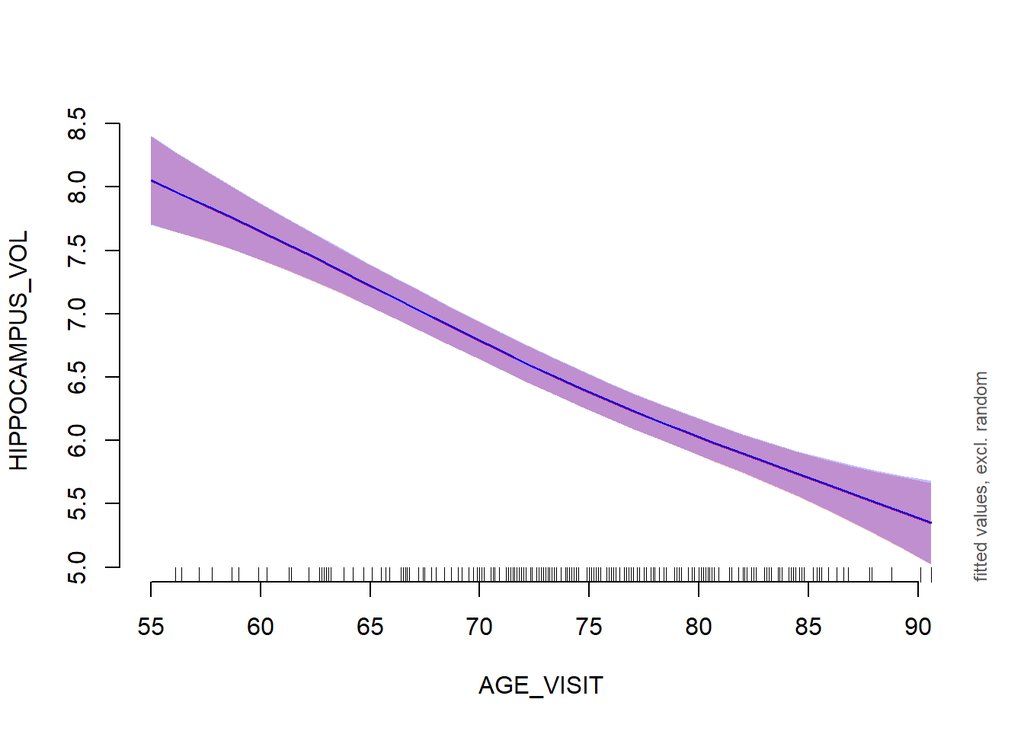

```
## Summary:
##  * DX : numeric predictor; set to the value(s): 1.
##  * PTGENDER : factor; set to the value(s): Male.
##  * APOE4 : factor; set to the value(s): 0.
##  * AGE_VISIT : numeric predictor; with 30 values ranging from 55.000000 to 90.600000.
##  * PTEDUCAT : numeric predictor; set to the value(s): 16.
##  * NOTE : No random effects in the model to cancel.
##
```

```r
itsadug::plot_smooth(q2, view="AGE_VISIT", add=TRUE, col="blue")
```

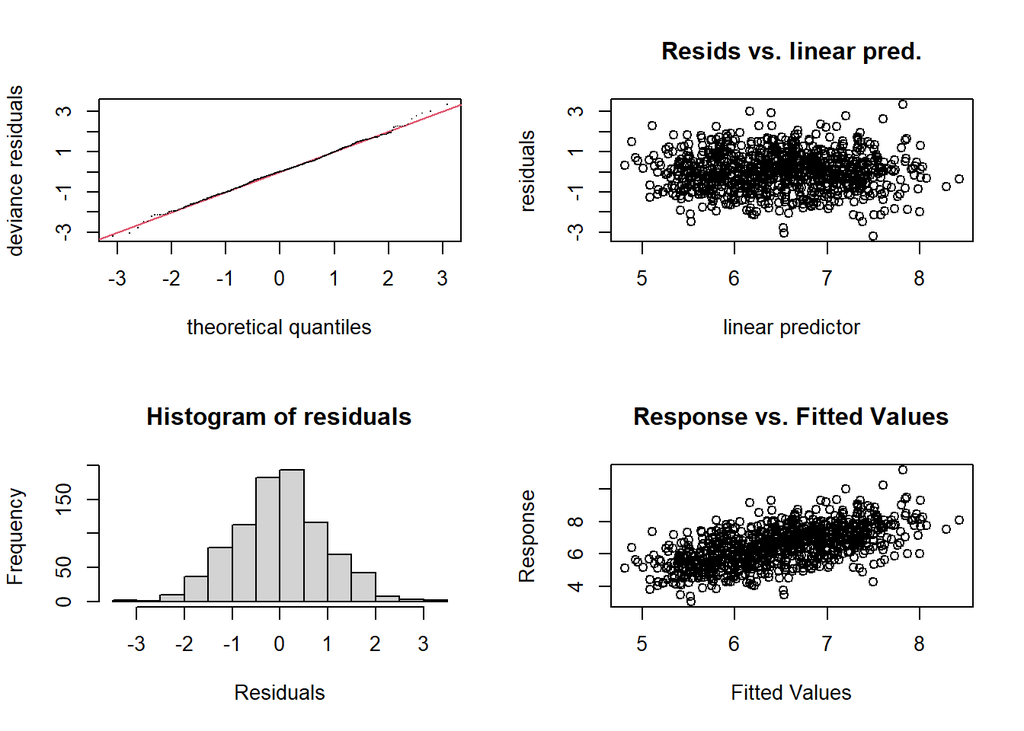

```
##
## Method: REML   Optimizer: outer newton
## full convergence after 5 iterations.
## Gradient range [-0.0001993398,0.0001949697]
## (score 1185.752 & scale 0.903817).
## Hessian positive definite, eigenvalue range [0.1181107,425.5007].
## Model rank =  23 / 23
##
## Basis dimension (k) checking results. Low p-value (k-index<1) may
## indicate that k is too low, especially if edf is close to k'.
##
##                k'  edf k-index p-value
## s(AGE_VISIT) 9.00 2.00    1.01   0.565
## s(PTEDUCAT)  9.00 1.75    0.93   0.025 *
## ---
## Signif. codes:  0 '***' 0.001 '**' 0.01 '*' 0.05 '.' 0.1 ' ' 1
```

```r
gam.check(q14)
```

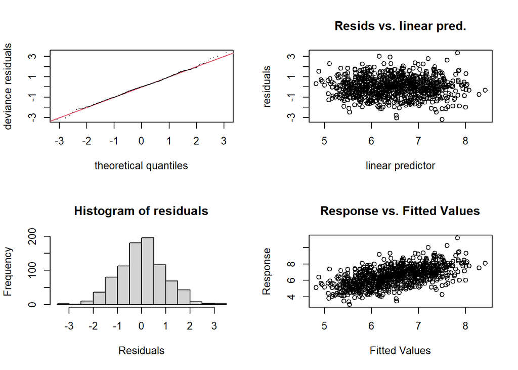

```
##
## Method: GCV   Optimizer: magic
## Smoothing parameter selection converged after 6 iterations.
## The RMS GCV score gradient at convergence was 3.819307e-06 .
## The Hessian was positive definite.
## Model rank =  23 / 23
##
## Basis dimension (k) checking results. Low p-value (k-index<1) may
## indicate that k is too low, especially if edf is close to k'.
##
##                k'  edf k-index p-value
## s(AGE_VISIT) 9.00 2.05    1.01   0.580
## s(PTEDUCAT)  9.00 1.94    0.93   0.025 *
## ---
## Signif. codes:  0 '***' 0.001 '**' 0.01 '*' 0.05 '.' 0.1 ' ' 1
```

```r
gam.check(q2)
```

## 1.16

Keep using the model from 1.14. Create a plot with simultaneous confidence intervals for the smoother for `AGE_VISIT`. Do this using the package `itsadug()`, `plot_smooth`, and `sim.ci=TRUE`. A nice blog post on simultaneous confidence intervals is https://fromthebottomoftheheap.net/2016/12/15/simultaneous-interval-revisited/. How does the confidence interval compare to the plot that has pointwise confidence bands?

The simultaneous CIs are larger than that of the pointwise confidence bands.

```r
itsadug::plot_smooth(q14, view="AGE_VISIT", sim.ci = TRUE, col="orange")
```

```
## Summary:
##  * DX : numeric predictor; set to the value(s): 1.
##  * PTGENDER : factor; set to the value(s): Male.
##  * APOE4 : factor; set to the value(s): 0.
##  * AGE_VISIT : numeric predictor; with 200 values ranging from 55.000000 to 90.600000.
##  * PTEDUCAT : numeric predictor; set to the value(s): 16.
##  * NOTE : No random effects in the model to cancel.
##
##  * Simultaneous 95%-CI used :
##      Critical value: 2.682
##      Proportion posterior simulations in pointwise CI: 0.57 (10000 samples)
##      Proportion posterior simulations in simultaneous CI: 0.95 (10000 samples)
##
```

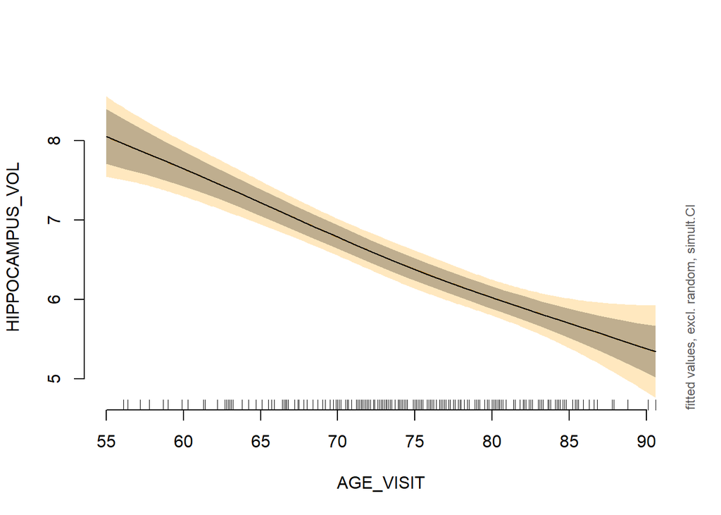

```
## Summary:
##  * DX : numeric predictor; set to the value(s): 1.
##  * PTGENDER : factor; set to the value(s): Male.
##  * APOE4 : factor; set to the value(s): 0.
##  * AGE_VISIT : numeric predictor; with 30 values ranging from 55.000000 to 90.600000.
##  * PTEDUCAT : numeric predictor; set to the value(s): 16.
##  * NOTE : No random effects in the model to cancel.
##
```

```r
itsadug::plot_smooth(q14, view="AGE_VISIT", add = TRUE)
```

## 1.17

What is the effect of an increase in patient age (`AGE_VISIT`) from 59 to 60 years? For simplicity, do not include CI here.

The effect of an increase in patient age from 59 to 60 years is a 0.08210043 cm^3 decrease in hippocampal volume, controlling for all other covariates.

```r
q17a <- predict(q14, data.frame(DX=1, PTGENDER="Male", APOE4 = 0, AGE_VISIT = 59, PTEDUCAT = 16), type="lpmatrix")
q17b <- predict(q14, data.frame(DX=1, PTGENDER="Male", APOE4 = 0, AGE_VISIT = 60, PTEDUCAT = 16), type="lpmatrix")

q17diff <- q17b-q17a
dim(q17b-q17a)
```

```
## [1]  1 23
```

```r
q17diff %*% coef(q14)
```

```
##          [,1]
## 1 -0.08210043
```

## 1.18

What is the effect of an increase in patient age (`AGE_VISIT`) from 80 to 81 years? For simplicity, do not include CI.

The effect of an increase in patient age from 80 to 81 years is a 0.0659635 cm^3 decrease in hippocampal volume, controlling for all other covariates.

```r
q18a <- predict(q14, data.frame(DX=1, PTGENDER="Male", APOE4 = 0, AGE_VISIT = 80, PTEDUCAT = 16), type="lpmatrix")
q18b <- predict(q14, data.frame(DX=1, PTGENDER="Male", APOE4 = 0, AGE_VISIT = 81, PTEDUCAT = 16), type="lpmatrix")

q18diff <- q18b-q18a
dim(q18b-q18a)
```

```
## [1]  1 23
```

```r
q18diff %*% coef(q14)
```

```
##         [,1]
## 1 -0.0659635
```

## 1.19

Does patient age, as measured with `AGE_VISIT`, impact hippocampal volume? State the approximate p-value and describe the pattern.

The approximate p-value is <2e-16. Hippocampal volume tends to decrease with `AGE_VISIT`. The decrease is slightly larger for younger ages.

```r
summary(q14)
```

```
##
## Family: gaussian
## Link function: identity
##
## Formula:
## HIPPOCAMPUS_VOL ~ s(AGE_VISIT) + s(PTEDUCAT) + DX + PTGENDER +
##     APOE4
##
## Parametric coefficients:
##              Estimate Std. Error t value Pr(>|t|)
## (Intercept)   6.90933    0.06425 107.538  < 2e-16 ***
## DX           -0.86315    0.07040 -12.261  < 2e-16 ***
## PTGENDERMale  0.42771    0.06699   6.385 2.82e-10 ***
## APOE41       -0.23459    0.07088  -3.310 0.000974 ***
## APOE42       -0.69569    0.12882  -5.400 8.63e-08 ***
## ---
## Signif. codes:  0 '***' 0.001 '**' 0.01 '*' 0.05 '.' 0.1 ' ' 1
##
## Approximate significance of smooth terms:
##                edf Ref.df       F p-value
## s(AGE_VISIT) 2.005  2.544 100.718  <2e-16 ***
## s(PTEDUCAT)  1.752  2.213   0.712   0.556
## ---
## Signif. codes:  0 '***' 0.001 '**' 0.01 '*' 0.05 '.' 0.1 ' ' 1
##
## R-sq.(adj) =  0.342   Deviance explained = 34.7%
## -REML = 1185.8  Scale est. = 0.90382   n = 858
```

```r
itsadug::plot_smooth(q14, view="AGE_VISIT", sim.ci = TRUE, col="orange")
```

```
## Summary:
##  * DX : numeric predictor; set to the value(s): 1.
##  * PTGENDER : factor; set to the value(s): Male.
##  * APOE4 : factor; set to the value(s): 0.
##  * AGE_VISIT : numeric predictor; with 200 values ranging from 55.000000 to 90.600000.
##  * PTEDUCAT : numeric predictor; set to the value(s): 16.
##  * NOTE : No random effects in the model to cancel.
##
##  * Simultaneous 95%-CI used :
##      Critical value: 2.65
##      Proportion posterior simulations in pointwise CI: 0.57 (10000 samples)
##      Proportion posterior simulations in simultaneous CI: 0.95 (10000 samples)
##
```

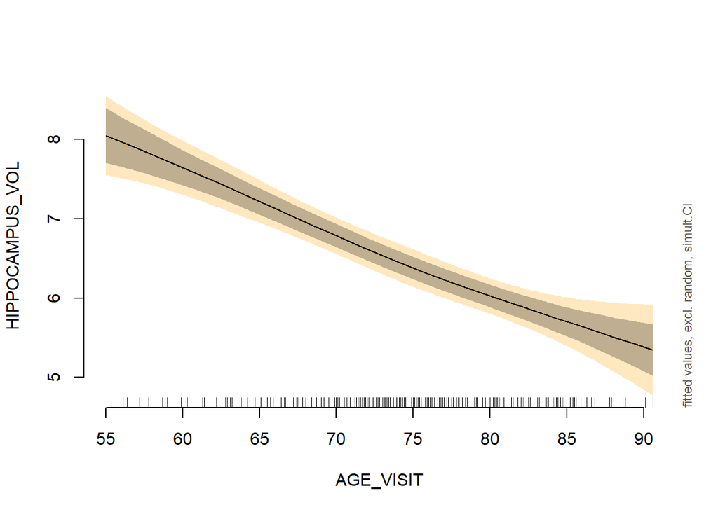

```
## Summary:
##  * DX : numeric predictor; set to the value(s): 1.
##  * PTGENDER : factor; set to the value(s): Male.
##  * APOE4 : factor; set to the value(s): 0.
##  * AGE_VISIT : numeric predictor; with 30 values ranging from 55.000000 to 90.600000.
##  * PTEDUCAT : numeric predictor; set to the value(s): 16.
##  * NOTE : No random effects in the model to cancel.
##
```

```r
itsadug::plot_smooth(q14, view="AGE_VISIT", add = TRUE)
```

## 1.20

We will now examine whether there is an interaction between `APOE4` (as a factor) and `AGE_VISIT`. Fit a model with a smoother for this interaction along with all previous terms (including smoother for `PTEDUCAT`). In practice, you could choose GCV or REML; to facilitate grading, use REML. Print the output of summary.

```r
q20 <- gam(HIPPOCAMPUS_VOL~DX+PTGENDER+APOE4 + s(PTEDUCAT)+ s(AGE_VISIT, by = APOE4), data= mcidata_cx, method="REML")
summary(q20)
```

```
##
## Family: gaussian
## Link function: identity
##
## Formula:
## HIPPOCAMPUS_VOL ~ DX + PTGENDER + APOE4 + s(PTEDUCAT) + s(AGE_VISIT,
##     by = APOE4)
##
## Parametric coefficients:
##              Estimate Std. Error t value Pr(>|t|)
## (Intercept)   6.90629    0.06407 107.794  < 2e-16 ***
## DX           -0.85237    0.07039 -12.109  < 2e-16 ***
## PTGENDERMale  0.42738    0.06692   6.387 2.80e-10 ***
## APOE41       -0.23919    0.07042  -3.397 0.000714 ***
## APOE42       -0.59481    0.13810  -4.307 1.85e-05 ***
## ---
## Signif. codes:  0 '***' 0.001 '**' 0.01 '*' 0.05 '.' 0.1 ' ' 1
##
## Approximate significance of smooth terms:
##                       edf Ref.df      F  p-value
## s(PTEDUCAT)         1.774  2.243  0.746 0.539747
## s(AGE_VISIT):APOE40 3.033  3.830 41.693  < 2e-16 ***
## s(AGE_VISIT):APOE41 1.477  1.822 54.538  < 2e-16 ***
## s(AGE_VISIT):APOE42 3.368  4.215  5.407 0.000229 ***
## ---
## Signif. codes:  0 '***' 0.001 '**' 0.01 '*' 0.05 '.' 0.1 ' ' 1
##
## R-sq.(adj) =  0.351   Deviance explained = 36.1%
## -REML = 1185.4  Scale est. = 0.89114   n = 858
```

## 1.21

Does the default $k=10$ appear to be adequate for all smooth terms?

Yes, it seems to be adequate since edfs are notably smaller than k’.

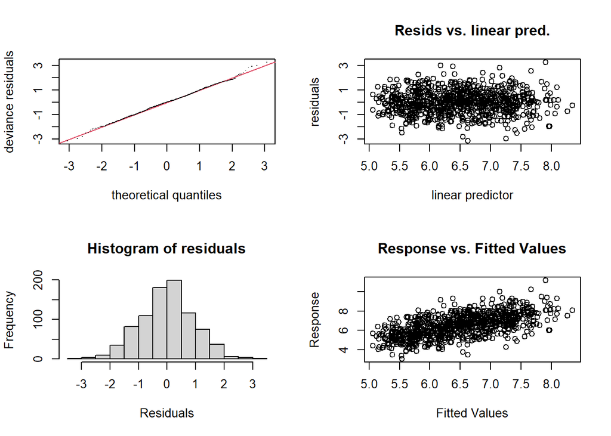

```
##
## Method: REML   Optimizer: outer newton
## full convergence after 5 iterations.
## Gradient range [-9.825084e-05,3.109543e-07]
## (score 1185.441 & scale 0.8911414).
## Hessian positive definite, eigenvalue range [0.08861142,424.5063].
## Model rank =  41 / 41
##
## Basis dimension (k) checking results. Low p-value (k-index<1) may
## indicate that k is too low, especially if edf is close to k'.
##
##                       k'  edf k-index p-value
## s(PTEDUCAT)         9.00 1.77    0.94   0.025 *
## s(AGE_VISIT):APOE40 9.00 3.03    1.02   0.705
## s(AGE_VISIT):APOE41 9.00 1.48    1.02   0.805
## s(AGE_VISIT):APOE42 9.00 3.37    1.02   0.675
## ---
## Signif. codes:  0 '***' 0.001 '**' 0.01 '*' 0.05 '.' 0.1 ' ' 1
```

```r
gam.check(q20)
```

## 1.22

Create plots to visually assess whether there is an interaction between `APOE4` and `AGE_VISIT`. Use simultaneous confidence intervals and overlay the plots. One way to do this is by adapting the code `cond = list('APOE4'='yourlevel'),add=TRUE,` etc.

```r
itsadug::plot_smooth(q20, view="AGE_VISIT", sim.ci = TRUE, col="orange", cond = list('APOE4'=0))
```

```
## Summary:
##  * DX : numeric predictor; set to the value(s): 1.
##  * PTGENDER : factor; set to the value(s): Male.
##  * APOE4 : numeric predictor; set to the value(s): 0.
##  * PTEDUCAT : numeric predictor; set to the value(s): 16.
##  * AGE_VISIT : numeric predictor; with 200 values ranging from 55.000000 to 90.600000.
##  * NOTE : No random effects in the model to cancel.
##
##  * Simultaneous 95%-CI used :
##      Critical value: 2.811
##      Proportion posterior simulations in pointwise CI: 0.4 (10000 samples)
##      Proportion posterior simulations in simultaneous CI: 0.95 (10000 samples)
##
```

```r
itsadug::plot_smooth(q20, view="AGE_VISIT", sim.ci = TRUE, col="red", cond = list('APOE4'=1), add=TRUE)
```

```
## Summary:
##  * DX : numeric predictor; set to the value(s): 1.
##  * PTGENDER : factor; set to the value(s): Male.
##  * APOE4 : numeric predictor; set to the value(s): 1.
##  * PTEDUCAT : numeric predictor; set to the value(s): 16.
##  * AGE_VISIT : numeric predictor; with 200 values ranging from 55.000000 to 90.600000.
##  * NOTE : No random effects in the model to cancel.
##
##  * Simultaneous 95%-CI used :
##      Critical value: 2.705
##      Proportion posterior simulations in pointwise CI: 0.45 (10000 samples)
##      Proportion posterior simulations in simultaneous CI: 0.95 (10000 samples)
##
```

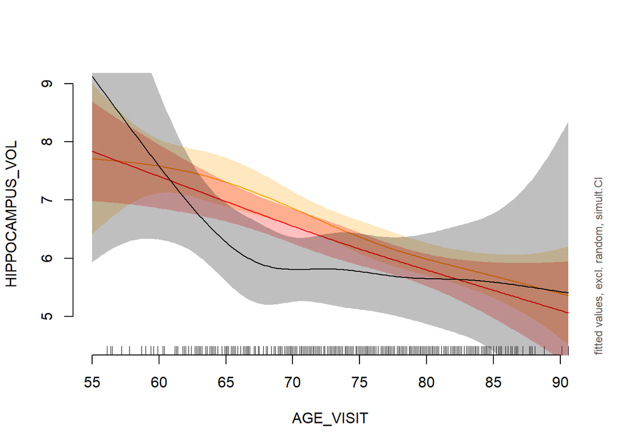

```
## Summary:
##  * DX : numeric predictor; set to the value(s): 1.
##  * PTGENDER : factor; set to the value(s): Male.
##  * APOE4 : numeric predictor; set to the value(s): 2.
##  * PTEDUCAT : numeric predictor; set to the value(s): 16.
##  * AGE_VISIT : numeric predictor; with 200 values ranging from 55.000000 to 90.600000.
##  * NOTE : No random effects in the model to cancel.
##
##  * Simultaneous 95%-CI used :
##      Critical value: 2.898
##      Proportion posterior simulations in pointwise CI: 0.46 (10000 samples)
##      Proportion posterior simulations in simultaneous CI: 0.95 (10000 samples)
##
```

```r
itsadug::plot_smooth(q20, view="AGE_VISIT", sim.ci = TRUE, cond = list('APOE4'=2), add=TRUE)
```

## 1.23

Using the gam with the interaction, what is the derivative of the smooth term for `AGE_VISIT` and `APOE4`=0 at `AGE_VISIT`=60? What is it for `AGE_VISIT`=75 and `APOE4`=0? (Hint: you can use finite differences.)

The derivative of the smooth term for `AGE_VISIT` and `APOE4`=0 at `AGE_VISIT`=60 is -0.03594941. For `AGE_VISIT`=75 and `APOE4`=0 it is -0.09095349.

```r
q23a1 <- predict(q20, data.frame(DX=1, PTGENDER="Male", APOE4 = 0, AGE_VISIT = 60+1e-05, PTEDUCAT = 16))
q23a2 <- predict(q20, data.frame(DX=1, PTGENDER="Male", APOE4 = 0, AGE_VISIT = 60-1e-05, PTEDUCAT = 16))
q23b1 <- predict(q20, data.frame(DX=1, PTGENDER="Male", APOE4 = 0, AGE_VISIT = 75+1e-05, PTEDUCAT = 16))
q23b2 <- predict(q20, data.frame(DX=1, PTGENDER="Male", APOE4 = 0, AGE_VISIT = 75-1e-05, PTEDUCAT = 16))


q23adiff <- q23a1-q23a2
q23adiff/2e-05
```

```
##           1
## -0.03594941
```

```r
q23bdiff <- q23b1-q23b2
q23bdiff/2e-05
```

```
##           1
## -0.09095349
```

## 1.24

What is the derivative of the smooth term for `AGE_VISIT` for `APOE4`=2 at `AGE_VISIT`=60? What is it for `AGE_VISIT`=75 and `APOE4`=2?

The derivative of the smooth term for `AGE_VISIT` for `APOE4`=2 at `AGE_VISIT`=60 is -0.2976912. For `AGE_VISIT`=75 and `APOE4`=2 it is -0.0305863.

```r
q24a1 <- predict(q20, data.frame(DX=1, PTGENDER="Male", APOE4 = 2, AGE_VISIT = 60+1e-05, PTEDUCAT = 16))
q24a2 <- predict(q20, data.frame(DX=1, PTGENDER="Male", APOE4 = 2, AGE_VISIT = 60-1e-05, PTEDUCAT = 16))
q24b1 <- predict(q20, data.frame(DX=1, PTGENDER="Male", APOE4 = 2, AGE_VISIT = 75+1e-05, PTEDUCAT = 16))
q24b2 <- predict(q20, data.frame(DX=1, PTGENDER="Male", APOE4 = 2, AGE_VISIT = 75-1e-05, PTEDUCAT = 16))


q24adiff <- q24a1-q24a2
q24adiff/2e-05
```

```
##          1
## -0.2976912
```

```r
q24bdiff <- q24b1-q24b2
q24bdiff/2e-05
```

```
##          1
## -0.0305863
```

## 1.25

In words, describe how the effect of age is modified by `APOE4`.

## 1.26

Conduct an approximate F test for the interaction between `APOE4` and the smooth for `AGE_VISIT` in the gam. Report the F-statistic, DF numerator and denominator, p-value, and your conclusion.

H0: The interaction between APOE4 and the smooth for AGE_VISIT does not contribute to the model for hippocampal volume.  
H1: The interaction between APOE4 and the smooth for AGE_VISIT does contribute to the model for hippocampal volume.  
df numerator= 8.8  
df denom= 838  
F statistic=2.0402  
p-value=0.03368  
alpha=0.05  
Decision: Reject null hypothesis  
Conclusion: The interaction between APOE4 and the smooth for AGE_VISIT does contribute to the model for hippocampal volume.

```r
anova(q14, q20, test="F")
```

```
## Analysis of Deviance Table
##
## Model 1: HIPPOCAMPUS_VOL ~ s(AGE_VISIT) + s(PTEDUCAT) + DX + PTGENDER +
##     APOE4
## Model 2: HIPPOCAMPUS_VOL ~ DX + PTGENDER + APOE4 + s(PTEDUCAT) + s(AGE_VISIT,
##     by = APOE4)
##   Resid. Df Resid. Dev     Df Deviance      F  Pr(>F)
## 1    847.24     767.56
## 2    838.43     751.54 8.8111    16.02 2.0402 0.03368 *
## ---
## Signif. codes:  0 '***' 0.001 '**' 0.01 '*' 0.05 '.' 0.1 ' ' 1
```

## 1.27

Fit a linear model (no smooth terms) with the same terms and report the F-statistic, DF numerator and denominator, pvalue, and your conclusion according to this linear model for the interaction between `APOE4` and `AGE_VISIT`.

H0: The interaction between APOE4 and AGE_VISIT does not contribute to the model for hippocampal volume.  
H1: The interaction between APOE4 and AGE_VISIT does contribute to the model for hippocampal volume.  
df numerator= 2  
df denom= 849  
F statistic=0.4385  
p-value=0.6452  
alpha=0.05  
Decision: Fail to reject null hypothesis  
Conclusion: The interaction between APOE4 and AGE_VISIT does not contribute to the model for hippocampal volume.

```r
q27 <- lm(HIPPOCAMPUS_VOL~AGE_VISIT+PTEDUCAT+DX+PTGENDER+APOE4 +AGE_VISIT*APOE4, data= mcidata_cx)
q27a <- lm(HIPPOCAMPUS_VOL~AGE_VISIT+PTEDUCAT+DX+PTGENDER+APOE4, data= mcidata_cx)

summary(q27)
```

```
##
## Call:
## lm(formula = HIPPOCAMPUS_VOL ~ AGE_VISIT + PTEDUCAT + DX + PTGENDER +
##     APOE4 + AGE_VISIT * APOE4, data = mcidata_cx)
##
## Residuals:
##     Min      1Q  Median      3Q     Max
## -3.1457 -0.6434  0.0079  0.5953  3.3688
##
## Coefficients:
##                   Estimate Std. Error t value Pr(>|t|)
## (Intercept)      12.899048   0.524846  24.577  < 2e-16 ***
## AGE_VISIT        -0.079683   0.006439 -12.374  < 2e-16 ***
## PTEDUCAT         -0.006235   0.011789  -0.529    0.597
## DX               -0.849055   0.069691 -12.183  < 2e-16 ***
## PTGENDERMale      0.420884   0.067302   6.254 6.35e-10 ***
## APOE41           -0.361155   0.767523  -0.471    0.638
## APOE42           -1.965712   1.362563  -1.443    0.149
## AGE_VISIT:APOE41  0.001651   0.010326   0.160    0.873
## AGE_VISIT:APOE42  0.017738   0.018960   0.936    0.350
## ---
## Signif. codes:  0 '***' 0.001 '**' 0.01 '*' 0.05 '.' 0.1 ' ' 1
##
## Residual standard error: 0.9532 on 849 degrees of freedom
## Multiple R-squared:  0.3442, Adjusted R-squared:  0.338
## F-statistic: 55.69 on 8 and 849 DF,  p-value: < 2.2e-16
```

```r
anova(q27a, q27)
```

```
## Analysis of Variance Table
##
## Model 1: HIPPOCAMPUS_VOL ~ AGE_VISIT + PTEDUCAT + DX + PTGENDER + APOE4
## Model 2: HIPPOCAMPUS_VOL ~ AGE_VISIT + PTEDUCAT + DX + PTGENDER + APOE4 +
##     AGE_VISIT * APOE4
##   Res.Df    RSS Df Sum of Sq      F Pr(>F)
## 1    851 772.24
## 2    849 771.44  2   0.79687 0.4385 0.6452
```

## 1.28

Which model do you prefer: the gam with interactions or the linear model with interactions? Why?

I prefer the GAM because some of the edfs are greater than 1, which means that it seems reasonable to use the smooth term. Additionally, interaction terms are significant in the GAM.